# CANTO - preprocessing

## Hormonotherapy type

```r
data.work$ht_type <- factor(NA, levels = c("tamoxifen","aromatase inhibitor", "others"))
data.work$ht_type[which(data.work$ht %in% c("yes") & data.work$hormono_first %in% c("tamoxifen"))] <- "tamoxifen"
data.work$ht_type[which(data.work$ht %in% c("yes") & data.work$hormono_first %in% c("aromatase inhibitor"))] <- "aromatase inhibitor"
data.work$ht_type[which(data.work$ht %in% c("yes") & data.work$hormono_first %in% c("agonist","others"))] <- "others"

summary(data.work$ht_type[which(data.work$ht == "yes")])
```

```
##           tamoxifen aromatase inhibitor              others                NA's
##                2973                4433                  88                  47
```

Find combination (first hormon therapy + another therapy within 1 month after the first one)

```r
data.work$month_horm1 <- as.numeric(substr(data.work$date_horm1, start = 6, stop = 7))
data.work$month_horm2 <- as.numeric(substr(data.work$date_horm2, start = 6, stop = 7))
data.work$month_horm3 <- as.numeric(substr(data.work$date_horm3, start = 6, stop = 7))
data.work$month_horm4 <- as.numeric(substr(data.work$date_horm4, start = 6, stop = 7))
data.work$month_horm5 <- as.numeric(substr(data.work$date_horm5, start = 6, stop = 7))
data.work$month_horm6 <- as.numeric(substr(data.work$date_horm6, start = 6, stop = 7))
data.work$month_horm7 <- as.numeric(substr(data.work$date_horm7, start = 6, stop = 7))


data.work$sec_date_hormono <- rep(NA, nrow(data.work))
data.work$sec_date_hormono[which(data.work$ht %in% c("yes") & data.work$min_date_hormono!=data.work$date_horm1 &
                                   abs(data.work$min_month_hormono-data.work$month_horm1)<=1)] <-
                as.character(data.work$date_horm1[which(data.work$ht %in% c("yes") &
                                                          data.work$min_date_hormono!=data.work$date_horm1 &                                                                                                                                  abs(data.work$min_month_hormono-data.work$month_horm1)<=1)])

data.work$sec_date_hormono[which(data.work$ht %in% c("yes") & data.work$min_date_hormono!=data.work$date_horm2 &
                                   abs(data.work$min_month_hormono-data.work$month_horm2)<=1)] <- as.character(data.work$date_horm2[which(data.work$ht %in% c("yes") & data.work$min_date_hormono!=data.work$date_horm2 &
                                  abs(data.work$min_month_hormono-data.work$month_horm2)<=1)])

data.work$sec_date_hormono[which(data.work$ht %in% c("yes") & data.work$min_date_hormono!=data.work$date_horm3 &
                                   abs(data.work$min_month_hormono-data.work$month_horm3)<=1)] <- as.character(data.work$date_horm1[which(data.work$ht %in% c("yes") & data.work$min_date_hormono!=data.work$date_horm3 &                                                                                                                                        abs(data.work$min_month_hormono-data.work$month_horm3)<=1)])
data.work$sec_date_hormono[which(data.work$ht %in% c("yes") & data.work$min_date_hormono!=data.work$date_horm4 &
                                   abs(data.work$min_month_hormono-data.work$month_horm4)<=1)] <- as.character(data.work$date_horm1[which(data.work$ht %in% c("yes") & data.work$min_date_hormono!=data.work$date_horm4 &
                                                                                                                                            abs(data.work$min_month_hormono-data.work$month_horm4)<=1)])
data.work$sec_date_hormono[which(data.work$ht %in% c("yes") & data.work$min_date_hormono!=data.work$date_horm5 &
                                   abs(data.work$min_month_hormono-data.work$month_horm5)<=1)] <- as.character(data.work$date_horm1[which(data.work$ht %in% c("yes") & data.work$min_date_hormono!=data.work$date_horm5 &
                                                                                                                                            abs(data.work$min_month_hormono-data.work$month_horm5)<=1)])
data.work$sec_date_hormono[which(data.work$ht %in% c("yes") & data.work$min_date_hormono!=data.work$date_horm6 &
                                   abs(data.work$min_month_hormono-data.work$month_horm6)<=1)] <- as.character(data.work$date_horm1[which(data.work$ht %in% c("yes") & data.work$min_date_hormono!=data.work$date_horm6 &
                                                                                                                                            abs(data.work$min_month_hormono-data.work$month_horm6)<=1)])
data.work$sec_date_hormono[which(data.work$ht %in% c("yes") & data.work$min_date_hormono!=data.work$date_horm7 &
                                   abs(data.work$min_month_hormono-data.work$month_horm7)<=1)] <- as.character(data.work$date_horm1[which(data.work$ht %in% c("yes") & data.work$min_date_hormono!=data.work$date_horm7 &
                                                                                                                                            abs(data.work$min_month_hormono-data.work$month_horm7)<=1)])


# find hormono therapy of the second date
data.work$hormono_second <- factor(NA, levels = c("tamoxifen","aromatase inhibitor","agonist","others"))
data.work$hormono_second[which(data.work$ht %in% c("yes") & data.work$sec_date_hormono==data.work$date_horm1)] <-
  data.work$horm_1[which(data.work$ht %in% c("yes") & data.work$sec_date_hormono==data.work$date_horm1)]

data.work$hormono_second[which(data.work$ht %in% c("yes") & data.work$sec_date_hormono==data.work$date_horm2)] <-
  data.work$horm_2[which(data.work$ht %in% c("yes") & data.work$sec_date_hormono==data.work$date_horm2)]

data.work$hormono_second[which(data.work$ht %in% c("yes") & data.work$sec_date_hormono==data.work$date_horm3)] <-
  data.work$horm_3[which(data.work$ht %in% c("yes") & data.work$sec_date_hormono==data.work$date_horm3)]

data.work$hormono_second[which(data.work$ht %in% c("yes") & data.work$sec_date_hormono==data.work$date_horm4)] <-
  data.work$horm_4[which(data.work$ht %in% c("yes") & data.work$sec_date_hormono==data.work$date_horm4)]

data.work$hormono_second[which(data.work$ht %in% c("yes") & data.work$sec_date_hormono==data.work$date_horm5)] <-
  data.work$horm_5[which(data.work$ht %in% c("yes") & data.work$sec_date_hormono==data.work$date_horm5)]

data.work$hormono_second[which(data.work$ht %in% c("yes") & data.work$sec_date_hormono==data.work$date_horm6)] <-
  data.work$horm_6[which(data.work$ht %in% c("yes") & data.work$sec_date_hormono==data.work$date_horm6)]

data.work$hormono_second[which(data.work$ht %in% c("yes") & data.work$sec_date_hormono==data.work$date_horm7)] <-
  data.work$horm_7[which(data.work$ht %in% c("yes") & data.work$sec_date_hormono==data.work$date_horm7)]


# first_ second hormono therapy
data.work$ht_type_5cl <- factor(NA, levels = c("tamoxifen","aromatase inhibitor",
                                              "tamoxifen + agonist","aromatase inhibitor + agonist",
                                              "others"))

data.work$ht_type_5cl[which(data.work$ht %in% c("yes") & data.work$hormono_first %in% c("tamoxifen") &
          is.na(data.work$hormono_second))] <- "tamoxifen"

data.work$ht_type_5cl[which(data.work$ht %in% c("yes") & data.work$hormono_first %in% c("tamoxifen") &
          data.work$hormono_second %in% c("tamoxifen","aromatase inhibitor","others"))] <- "tamoxifen"

data.work$ht_type_5cl[which(data.work$ht %in% c("yes") & data.work$hormono_first %in% c("tamoxifen") &
          data.work$hormono_second %in% c("agonist"))] <- "tamoxifen + agonist"

data.work$ht_type_5cl[which(data.work$ht %in% c("yes") & data.work$hormono_first %in% c("agonist") &
          data.work$hormono_second %in% c("tamoxifen"))] <- "tamoxifen + agonist"

data.work$ht_type_5cl[which(data.work$ht %in% c("yes") & data.work$hormono_first %in% c("aromatase inhibitor") &
          is.na(data.work$hormono_second))] <- "aromatase inhibitor"

data.work$ht_type_5cl[which(data.work$ht %in% c("yes") & data.work$hormono_first %in% c("aromatase inhibitor") &
          data.work$hormono_second %in% c("aromatase inhibitor","tamoxifen","others"))] <- "aromatase inhibitor"

data.work$ht_type_5cl[which(data.work$ht %in% c("yes") & data.work$hormono_first %in% c("aromatase inhibitor") &
          data.work$hormono_second %in% c("agonist"))] <- "aromatase inhibitor + agonist"

data.work$ht_type_5cl[which(data.work$ht %in% c("yes") & data.work$hormono_first %in% c("agonist") &
          data.work$hormono_second %in% c("aromatase inhibitor"))] <- "aromatase inhibitor + agonist"

data.work$ht_type_5cl[which(data.work$ht %in% c("yes") & data.work$hormono_first %in% c("agonist") &
          is.na(data.work$hormono_second))] <- "others"

data.work$ht_type_5cl[which(data.work$ht %in% c("yes") & data.work$hormono_first %in% c("agonist") &
          data.work$hormono_second %in% c("agonist"))] <- "others"

data.work$ht_type_5cl[which(data.work$ht %in% c("yes") & data.work$hormono_first %in% c("others"))] <- "others"

table(data.work$ht_type_5cl[which(data.work$ht=='yes')], exclude = NULL)
```

```
##
##                     tamoxifen           aromatase inhibitor
##                          2967                          4429
##           tamoxifen + agonist aromatase inhibitor + agonist
##                             7                             7
##                        others                          <NA>
##                            84                            47
```

See the values for patients with ht_type_5cl = NA

```r
rr= data.work[which(is.na(data.work$ht_type_5cl) & data.work$ht %in% c("yes")),c('ht_type',"hormono_first","hormono_second", "date_horm1", 'horm_1', "date_horm2", 'horm_2', 'horm_3', 'horm_4', 'horm_5', 'horm_6', 'horm_7')]
rr
```

|  | ht_type | hormono_first | hormono_second | date_horm1 | horm_1 | date_horm2 | horm_2 | horm_3 | horm_4 | horm_5 | horm_6 | horm_7 |
| --- | --- | --- | --- | --- | --- | --- | --- | --- | --- | --- | --- | --- |
| 263 | NA | NA | NA |  | NA |  | NA | NA | NA | NA | NA | NA |
| 719 | NA | NA | NA |  | NA |  | NA | NA | NA | NA | NA | NA |
| 1161 | NA | NA | NA |  | NA |  | NA | NA | NA | NA | NA | NA |
| 1293 | NA | NA | NA |  | NA |  | NA | NA | NA | NA | NA | NA |
| 1308 | NA | NA | NA |  | NA |  | NA | NA | NA | NA | NA | NA |
| 1681 | NA | NA | NA |  | NA |  | NA | NA | NA | NA | NA | NA |
| 2224 | NA | NA | NA |  | NA |  | NA | NA | NA | NA | NA | NA |
| 2807 | NA | NA | NA |  | NA |  | NA | NA | NA | NA | NA | NA |
| 2813 | NA | NA | NA |  | NA |  | NA | NA | NA | NA | NA | NA |
| 2826 | NA | NA | NA |  | NA |  | NA | NA | NA | NA | NA | NA |

[output cut: 37 more lines]

If only tamoxifen or only aromatase, assign to their class. If mixed, assign to others

```r
df_horm = data.work[,c('horm_1', 'horm_2', 'horm_3', 'horm_4', 'horm_5', 'horm_6', 'horm_7')]
df_horm = apply(df_horm,2,as.character)

l = unlist(lapply(1:nrow(df_horm), function(i){if(is.na(data.work$ht_type_5cl[i]) & length(na.omit(unique(df_horm[i,]))) > 0){if(paste(na.omit(unique(df_horm[i,])),collapse = ',') == "aromatase inhibitor") 'aromatase inhibitor' else NA} else NA }))
v = which(l=='aromatase inhibitor')
data.work$ht_type_5cl[v] <- "aromatase inhibitor"

l = unlist(lapply(1:nrow(df_horm), function(i){if(is.na(data.work$ht_type_5cl[i]) & length(na.omit(unique(df_horm[i,]))) > 0){if(paste(na.omit(unique(df_horm[i,])),collapse = ',') == "tamoxifen") 'tamoxifen' else NA} else NA }))
v = which(l=='tamoxifen')
data.work$ht_type_5cl[v] <- "tamoxifen"


l = unlist(lapply(1:nrow(df_horm), function(i){if(is.na(data.work$ht_type_5cl[i]) & length(na.omit(unique(df_horm[i,]))) > 0){if(paste(na.omit(unique(df_horm[i,])),collapse = ',') == c("tamoxifen,aromatase inhibitor")  | paste(na.omit(unique(df_horm[i,])),collapse = ',') == c("aromatase inhibitor,tamoxifen") ) 'others' else NA} else NA }))
v = which(l=='others')
data.work$ht_type_5cl[v] <- "others"

table(data.work$ht_type_5cl[which(data.work$ht=='yes')], exclude = NULL)
```

```
##
##                     tamoxifen           aromatase inhibitor
##                          2968                          4431
##           tamoxifen + agonist aromatase inhibitor + agonist
##                             7                             7
##                        others                          <NA>
##                            87                            41
```

See the values for patients with ht_type_5cl = NA

```r
rr= data.work[which(is.na(data.work$ht_type_5cl) & data.work$ht %in% c("yes")),c('ht_type',"hormono_first","hormono_second", "date_horm1", 'horm_1', "date_horm2", 'horm_2', 'horm_3', 'horm_4', 'horm_5', 'horm_6', 'horm_7')]
rr
```

|  | ht_type | hormono_first | hormono_second | date_horm1 | horm_1 | date_horm2 | horm_2 | horm_3 | horm_4 | horm_5 | horm_6 | horm_7 |
| --- | --- | --- | --- | --- | --- | --- | --- | --- | --- | --- | --- | --- |
| 263 | NA | NA | NA |  | NA |  | NA | NA | NA | NA | NA | NA |
| 719 | NA | NA | NA |  | NA |  | NA | NA | NA | NA | NA | NA |
| 1161 | NA | NA | NA |  | NA |  | NA | NA | NA | NA | NA | NA |
| 1293 | NA | NA | NA |  | NA |  | NA | NA | NA | NA | NA | NA |
| 1308 | NA | NA | NA |  | NA |  | NA | NA | NA | NA | NA | NA |
| 1681 | NA | NA | NA |  | NA |  | NA | NA | NA | NA | NA | NA |
| 2224 | NA | NA | NA |  | NA |  | NA | NA | NA | NA | NA | NA |
| 2807 | NA | NA | NA |  | NA |  | NA | NA | NA | NA | NA | NA |
| 2813 | NA | NA | NA |  | NA |  | NA | NA | NA | NA | NA | NA |
| 2826 | NA | NA | NA |  | NA |  | NA | NA | NA | NA | NA | NA |

[output cut: 31 more lines]

# Target therapy

## Herceptine

```r
data.work$DTDEBHERCEP[which(data.work$DTDEBHERCEP=='')] = NA
data.work$DTFINHERCEP[which(data.work$DTFINHERCEP=='')] = NA

data.work$TC_info <- rep(NA, nrow(data.work))
vars_hercep = c("MODIFHERCEP","INTHERCEP","DTDEBHERCEP","NBCYCLHERCEP", "SCHEMAHERCEP", "VOIEHERCEP", "DOSE1HERCEP")
data.work$TC_info <- apply(data.work[,vars_hercep],1,function(x) sum(!is.na(x)))

data.work = imputeDate(data.work, 'DTDEBHERCEP')
data.work = imputeDate(data.work, 'DTFINHERCEP')

# Herceptin (Trastuzumab)
data.work$HERCEP[which(is.na(data.work$HERCEP))] = 0

data.work$trastu <- factor(NA, levels = c("no","yes"))
data.work$trastu[which(data.work$HERCEP %in% c("0"))] <- "no"
data.work$trastu[which(data.work$HERCEP %in% c("1"))] <- "yes"

table(variables_not_NA_hercep = data.work$TC_info, trastu = data.work$trastu, exclude = NULL)
```

```
##                        trastu
## variables_not_NA_hercep   no  yes
##                       0 8372    2
##                       1    2    1
##                       2    1    0
##                       3    0    2
##                       4    0    5
##                       5    0   29
##                       6    2 1073
##                       7    0   24
```

There are no NAs for herceptine status.

We have to check the information with the one present in the chemotherapy variables, some herceptine is reported there

```r
v = c(grep('HERCEPT',data.work$OTHSEQ1_ADJ ), grep('HERCEPT',data.work$OTHSEQ2_ADJ ), grep('HERCEPT',data.work$OTHSEQ1_NEO ), grep('HERCEPT',data.work$OTHSEQ2_NEO ))
data.work$trastu[v]
```

```
##  [1] yes yes yes yes yes yes yes yes no  yes yes yes yes
## Levels: no yes
```

### Check NO values

Here a table representing the variables regarding herceptine for people having herceptine set to no but information on herceptine (test the correctness of no herceptine):

```r
table(data.work$TC_info,data.work$trastu)
```

```
##
##       no  yes
##   0 8372    2
##   1    2    1
##   2    1    0
##   3    0    2
##   4    0    5
##   5    0   29
##   6    2 1073
##   7    0   24
```

```r
rr = data.work[which(data.work$trastu %in% c("no") & data.work$TC_info>0),vars_hercep]
rr
```

|  | MODIFHERCEP | INTHERCEP | DTDEBHERCEP | NBCYCLHERCEP | SCHEMAHERCEP | VOIEHERCEP | DOSE1HERCEP |
| --- | --- | --- | --- | --- | --- | --- | --- |
| 6318 | 0 | 0 | 15/07/2014 | 18 | 2 | 1 | NA |
| 6905 | 0 | 0 | NA | NA | NA | NA | NA |
| 7582 | NA | NA | NA | NA | NA | 1 | NA |
| 8385 | NA | NA | NA | 18 | NA | NA | NA |
| 9493 | 0 | 0 | 18/10/2016 | 16 | 2 | 1 | NA |

```r
v=which(data.work$trastu %in% c("no") & data.work$TC_info>0 & (!is.na(data.work$DTDEBHERCEP) | !is.na(data.work$NBCYCLHERCEP)))
```

Leave them set to NO

## modification dose of herceptin

```r
data.work$reduc_dos_tz <- factor(NA, levels = c("no","yes"))
data.work$reduc_dos_tz[which(data.work$trastu %in% c("yes") & data.work$MODIFHERCEP %in% c("0"))] <- "no"
data.work$reduc_dos_tz[which(data.work$trastu %in% c("yes") & data.work$MODIFHERCEP %in% c("1"))] <- "yes"
table(data.work$reduc_dos_tz, exclude = NULL)
```

```
##
##   no  yes <NA>
##  982  144 8387
```

## premature stop trastu

```r
data.work$stop_tz <- factor(NA, levels = c("no","yes"))
data.work$stop_tz[which(data.work$trastu %in% c("yes") & data.work$INTHERCEP %in% c("0"))] <- "no"
data.work$stop_tz[which(data.work$trastu %in% c("yes") & data.work$INTHERCEP %in% c("1"))] <- "yes"
table(data.work$stop_tz, exclude = NULL)
```

```
##
##   no  yes <NA>
## 1035   93 8385
```

# Other targeted therapy

```r
data.work$other_target_therapy <- factor(NA, levels = c("no","yes"))
data.work$other_target_therapy[which(data.work$CIBLE1 %in% c("0"))] <- "no"
data.work$other_target_therapy[which(data.work$CIBLE1 %in% c("1"))] <- "yes"
table(data.work$other_target_therapy, exclude = NULL)
```

```
##
##   no  yes <NA>
## 9127  277  109
```

## Check NA values

```r
data.work$DTDEBCIBLE1[which(data.work$DTDEBCIBLE1=='')] = NA
data.work$DTDEBCIBLE1[which(data.work$DTDEBCIBLE1=='')] = NA
data.work$NOMCIBLE1[which(data.work$NOMCIBLE1=='')] = NA

data.work$other_target_therapy_info <- rep(NA, nrow(data.work))
data.work$other_target_therapy_info <- apply(data.work[,c("NOMCIBLE1", "DTDEBCIBLE1", "NBCIBLE1", "POSOCIBLE1")],1,function(x) sum(!is.na(x)))

data.work = imputeDate(data.work, 'DTDEBCIBLE1')

table(variables_not_NA_othert_target_therapy = data.work$other_target_therapy_info, other_target_therapy = data.work$other_target_therapy, exclude = NULL)
```

```
##                                       other_target_therapy
## variables_not_NA_othert_target_therapy   no  yes <NA>
##                                      0 9125    0  109
##                                      2    0    5    0
##                                      3    0   44    0
##                                      4    2  228    0
```

We have 109 NAs, there is no information on target therapy variables, NAs values are to set to NO.

```r
data.work$other_target_therapy[which(is.na(data.work$other_target_therapy))] = "no"
```

Other targer therapy status distribution is now:

```r
summary(data.work$other_target_therapy)
```

```
##   no  yes
## 9236  277
```

## Check NO values

```r
table(variables_not_NA_othert_target_therapy = data.work$other_target_therapy_info, other_target_therapy = data.work$other_target_therapy, exclude = NULL)
```

```
##                                       other_target_therapy
## variables_not_NA_othert_target_therapy   no  yes
##                                      0 9234    0
##                                      2    0    5
##                                      3    0   44
##                                      4    2  228
```

```r
v = which(data.work$other_target_therapy == 'no' & data.work$other_target_therapy_info > 0 & data.work$NOMCIBLE1 != '')
rr= data.work[v,c("NOMCIBLE1", "DTDEBCIBLE1", "NBCIBLE1", "POSOCIBLE1")]
rr
```

|  | NOMCIBLE1 | DTDEBCIBLE1 | NBCIBLE1 | POSOCIBLE1 |
| --- | --- | --- | --- | --- |
| 67 | PERTUZUMAB | 11/01/2013 | 18 | 420 |
| 7409 | TRASTUZUMAB | 11/01/2013 | 3 | 588 |

Leave them set to NO

# Dates and first treatment

```r
#========= Surgery ===========

#Tumorectomie
data.work$DTTUMOR_G[which(data.work$DTTUMOR_G %in% "")] <- NA
data.work$DTTUMOR_D[which(data.work$DTTUMOR_D %in% "")] <- NA
data.work$DTTUMOR <- ifelse(data.work$breast_surg_side %in% c("L"), as.character(data.work$DTTUMOR_G), as.character(data.work$DTTUMOR_D))
data.work = imputeDate(data.work, 'DTTUMOR')
data.work$DTTUMOR = as.Date(data.work$DTTUMOR, format = "%d/%m/%Y")

#Quadrantectomie
data.work$DTQUADRA_G[which(data.work$DTQUADRA_G %in% "")] <- NA
data.work$DTQUADRA_D[which(data.work$DTQUADRA_D %in% "")] <- NA
data.work$DTQUADRA <- ifelse(data.work$breast_surg_side %in% c("L"), as.character(data.work$DTQUADRA_G), as.character(data.work$DTQUADRA_D))
data.work = imputeDate(data.work, 'DTQUADRA')
data.work$DTQUADRA = as.Date(data.work$DTQUADRA, format = "%d/%m/%Y")


#Mastectomie radicale
data.work$DTMASTR_G[which(data.work$DTMASTR_G %in% "")] <- NA
data.work$DTMASTR_D[which(data.work$DTMASTR_D %in% "")] <- NA
data.work$DTMASTR <- ifelse(data.work$breast_surg_side %in% c("L"), as.character(data.work$DTMASTR_G), as.character(data.work$DTMASTR_D))
data.work = imputeDate(data.work, 'DTMASTR')
data.work$DTMASTR = as.Date(data.work$DTMASTR, format = "%d/%m/%Y")

#Mastectomie sous-cutanee
data.work$DTMASTSC_G[which(data.work$DTMASTSC_G %in% "")] <- NA
data.work$DTMASTSC_D[which(data.work$DTMASTSC_D %in% "")] <- NA
data.work$DTMASTSC <- ifelse(data.work$breast_surg_side %in% c("L"), as.character(data.work$DTMASTSC_G), as.character(data.work$DTMASTSC_D))
data.work = imputeDate(data.work, 'DTMASTSC')
data.work$DTMASTSC = as.Date(data.work$DTMASTSC, format = "%d/%m/%Y")

#Curage axillaire
data.work$DTCURAGE_G[which(data.work$DTCURAGE_G %in% "")] <- NA
data.work$DTCURAGE_D[which(data.work$DTCURAGE_D %in% "")] <- NA
data.work$DTCURAGE <- ifelse(data.work$breast_surg_side %in% c("L"), as.character(data.work$DTCURAGE_G), as.character(data.work$DTCURAGE_D))
data.work = imputeDate(data.work, 'DTCURAGE')
data.work$DTCURAGE = as.Date(data.work$DTCURAGE, format = "%d/%m/%Y")

#Ganglion sentinelle
data.work$DTGANGLS_G[which(data.work$DTGANGLS_G %in% "")] <- NA
data.work$DTGANGLS_D[which(data.work$DTGANGLS_D %in% "")] <- NA
data.work$DTGANGLS <- ifelse(data.work$breast_surg_side %in% c("L"), as.character(data.work$DTGANGLS_G), as.character(data.work$DTGANGLS_D))
data.work = imputeDate(data.work, 'DTGANGLS')
data.work$DTGANGLS = as.Date(data.work$DTGANGLS, format = "%d/%m/%Y")

# date first surgery
data.work$date_surg_part <- pmin(data.work$DTTUMOR, data.work$DTQUADRA, data.work$DTMASTR,
                            data.work$DTMASTSC, na.rm = TRUE)

data.work$date_surg <- pmin(data.work$DTTUMOR, data.work$DTQUADRA, data.work$DTMASTR,
                            data.work$DTMASTSC, data.work$DTCURAGE, data.work$DTGANGLS, na.rm = TRUE)

data.work$date_first_axillar_surg = pmin(data.work$DTCURAGE, data.work$DTGANGLS, na.rm = TRUE)

data.work[,'date_surg_IMPUTED'] = 0
for(i in 1:nrow(data.work)){
  s = paste0(substr(data.work$date_surg[i],9,10), '/', substr(data.work$date_surg[i],6,7), '/', substr(data.work$date_surg[i],1,4) )
  if(!s %in% c(data.work$DTTUMOR_raw[i], data.work$DTQUADRA_raw[i], data.work$DTMASTR_raw[i],
                            data.work$DTMASTSC_raw[i], data.work$DTCURAGE_raw[i], data.work$DTGANGLS_raw[i]))
    data.work[i,'date_surg_IMPUTED'] = 1
}
```

## NA as surgery dates

[output not shown]

If right tumor date is NA, take the surgery date at left breast even if the person is marked as right tumor. It was probably reported in the wrong variable.

Surgery date not known

```r
surg_NA = which(is.na(data.work$date_surg) & data.work$surgery=="yes")

rr= cbind(data.frame(surg = data.work$surgery[surg_NA]) , data.work[surg_NA,c("side", "DTTUMOR_G", "DTTUMOR_D",
                                           "DTQUADRA_G", "DTQUADRA_D",
                                           "DTMASTR_G", "DTMASTR_D",
                                           "DTMASTSC_G", "DTMASTSC_D",
                                           "DTCURAGE_G", "DTCURAGE_D",
                                        "DTGANGLS_G", "DTGANGLS_D")])
rr
```

|  | surg | side | DTTUMOR_G | DTTUMOR_D | DTQUADRA_G | DTQUADRA_D | DTMASTR_G | DTMASTR_D | DTMASTSC_G | DTMASTSC_D | DTCURAGE_G | DTCURAGE_D | DTGANGLS_G | DTGANGLS_D |
| --- | --- | --- | --- | --- | --- | --- | --- | --- | --- | --- | --- | --- | --- | --- |
| 1158 | yes | L | K | NA | NA | NA | NA | NA | NA | NA | NA | NA | K | NA |
| 1879 | yes | R | NA | NA | NA | NA | NA | NA | NA | NA | NA | NA | NA | NA |
| 7151 | yes | R | NA | NA | NA | NA | NA | NA | NA | NA | NA | NA | NA | NA |
| 9001 | yes | R | NA | NA | NA | NA | NA | NA | NA | NA | NA | NA | NA | NA |

Chemotherapy and target therapy dates

## Type of treatment path

```
## surgery     NAC  others    NA's
##    7963    1279     150     121
```

We have 121 NAs values. See variables related to these patients to look for inconsistencies:

|  | surgery | date_surg | NAC_bin | NAC_regimen | DTDEBCYCLE_NEO | DTFINCYCLE_NEO | adj_bin | adj_regimen | DTDEBCYCLE_ADJ | DTFINCYCLE_ADJ | min_date_chimio_hormono_hercep_TC | DTDEBCIBLE1 | DTDEBHERCEP | min_date_hormono_hercep_TC | min_date_hormono |
| --- | --- | --- | --- | --- | --- | --- | --- | --- | --- | --- | --- | --- | --- | --- | --- |
| 15 | no |  | no | NA |  |  | no | NA |  |  |  |  |  |  |  |
| 49 | no |  | no | NA |  |  | no | NA |  |  |  |  |  |  |  |
| 97 | no |  | no | NA |  |  | no | NA |  |  |  |  |  |  |  |
| 166 | no |  | no | NA |  |  | no | NA |  |  |  |  |  |  |  |
| 282 | no |  | no | NA |  |  | no | NA |  |  |  |  |  |  |  |
| 291 | no |  | no | NA |  |  | no | NA |  |  |  |  |  |  |  |
| 301 | no |  | no | NA |  |  | no | NA |  |  |  |  |  |  |  |
| 316 | no |  | no | NA |  |  | no | NA |  |  |  |  |  |  |  |
| 322 | no |  | no | NA |  |  | no | NA |  |  |  |  |  |  |  |
| 326 | no |  | no | NA |  |  | no | NA |  |  |  |  |  |  |  |

[output cut: 111 more lines]

## Surgery date after adjuvant treatment

We have 64 patients with surgery date after adjuvant treatment. Is it a neoadj chemotherapy??? If yes, FIX

|  | parcours | date_surg | adj_bin | DTDEBCYCLE_ADJ | NAC_bin | DTDEBCYCLE_NEO | min_date_chimio_hormono_hercep_TC | min_date_hormono_hercep_TC | DTDEBCIBLE1 | DTDEBHERCEP | min_date_hormono | adj_regimen |
| --- | --- | --- | --- | --- | --- | --- | --- | --- | --- | --- | --- | --- |
| 82 | others | 2013-06-04 | yes | 2012-10-23 | no |  | 2012-10-23 | 2013-03-01 |  |  | 2013-03-01 | anthra-taxans |
| 198 | NAC | 2013-07-30 | yes | 2013-02-04 | yes | 2013-02-04 | 2013-02-04 | 2013-11-15 |  |  | 2013-11-15 | anthra-taxans |
| 335 | others | 2014-06-26 | yes | 2013-09-12 | no |  | 2013-09-12 | 2013-11-14 |  | 2013-11-14 |  | anthra-taxans |
| 380 | others | 2014-09-11 | yes | 2014-01-15 | no |  | 2014-01-15 | 2014-05-29 |  |  | 2014-05-29 | anthra-taxans |
| 392 | NAC | 2014-05-28 | yes | 2013-12-05 | yes |  | 2013-12-05 | 2014-09-15 |  |  | 2014-09-15 | anthra-taxans |
| 529 | others | 2015-06-05 | yes | 2014-08-13 | no |  | 2014-08-13 | 2015-02-17 |  |  | 2015-02-17 | anthra-taxans |
| 909 | others | 2015-05-20 | yes | 2015-05-19 | no |  | 2015-05-06 | 2015-05-06 | 2015-05-06 |  | 2015-12-15 | anthra-taxans |
| 1006 | others | 2017-07-31 | yes | 2015-10-09 | no |  | 2015-10-09 | 2016-10-19 |  |  | 2016-10-19 | anthra-taxans |
| 1019 | NA | 2015-08-20 | yes | 2015-07-15 | no |  | 2015-07-15 | 2016-03-15 |  |  | 2016-03-15 | anthra-taxans |
| 1040 | NA | 2015-09-02 | yes | 2015-01-30 | no |  | 2015-01-30 | 2016-05-31 |  |  | 2016-05-31 | anthra-taxans |

[output cut: 54 more lines]

# ER, PR, HER2

- Use only biopsy information when available.
- Use surgery information if the patient has no information on there variables in biopsy.
- Take the maximum between biopsy and surgery for HER2

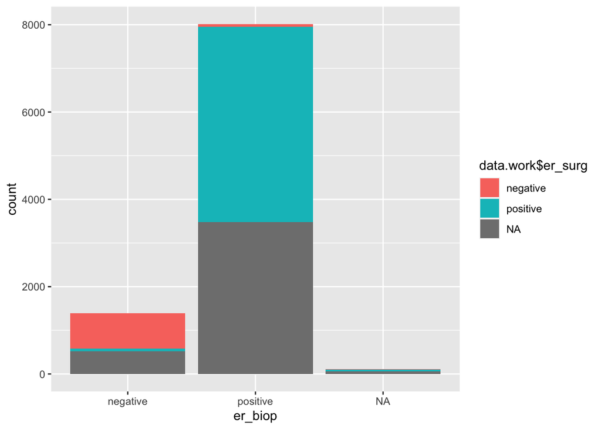

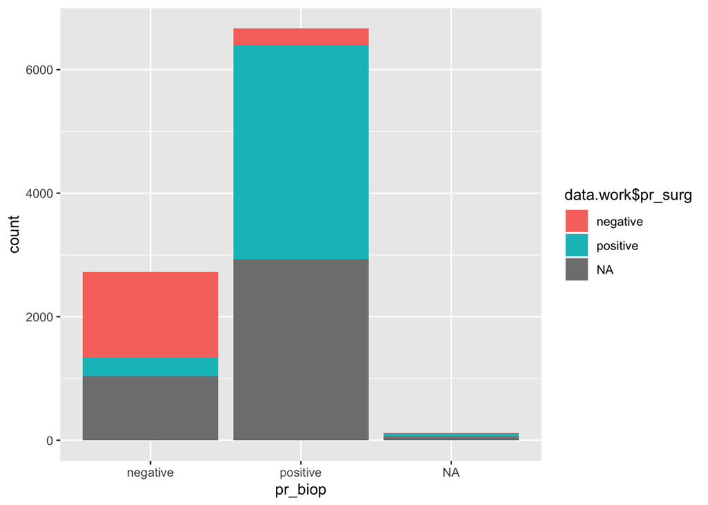

## ER status

ER percentage for invasive case, intensity of right side at biopsy (INTENSRE_D_BI) is not present

## PR status

```
## negative positive     NA's
##     2741     6713       59
```

ER percentage for invasive case

## Her2 status

```
## positive negative     NA's
##     1171     8250       92
```

# Toxicity

```r
data.work$GranulocyteToxicityMarker = rep(0, nrow(data.work))
data.work$doseReductionToxicityMarker = rep(0, nrow(data.work))

reductionDoseVars = c("REDUCDOSE_NEO","REDUCDOSE_ADJ")

growFactor = c("FACTCROISS_NEO","FACTCROISS_ADJ")

datesGrowFactor = c("DTDEBFACTCROISS_NEO", "DTDEBFACTCROISS_ADJ")

datesChemo = c("DTDEBCYCLE_NEO", "DTDEBCYCLE_ADJ")

for(j in length(growFactor)){
  for(i in 1:nrow(data.work)){
    if(data.work[i,growFactor[j]] %in% c(1)){
      date_g = as.Date(data.work[i, datesGrowFactor[j]], format = "%d/%m/%y")
      if(!is.na(date_g)){
        date_chem = data.work[i,datesChemo[j]]
        if(!is.na(date_chem)){
          if(date_chem < date_g){
            data.work$GranulocyteToxicityMarker[i] = 1
          }
        }
      }
    }
  }
}

data.work$doseReductionToxicityMarker[which(data.work$REDUCDOSE_NEO == 1 | data.work$REDUCDOSE_ADJ == 1)] = 1
data.work$toxicityMixed  =  data.work$doseReductionToxicityMarker + data.work$GranulocyteToxicityMarker
data.work$toxicityMixed[which(data.work$toxicityMixed == 2)] = "yes"
data.work$toxicityMixed[which(data.work$toxicityMixed == 1)] = "yes"
data.work$toxicityMixed[which(data.work$toxicityMixed == 0)] = "no"
```

```r
data.work$consult_prof <- factor(NA, levels = c("0", "1 to 5 times", "6 to 10 times", "More than 10 times"))
data.work$consult_prof[which(data.work$NBCONS_BI %in%
          c("","D","K"))] <- NA
data.work$consult_prof[which(data.work$NBCONS_BI %in% c("1"))] <- "0"
data.work$consult_prof[which(data.work$NBCONS_BI %in% c("2"))] <- "1 to 5 times"
data.work$consult_prof[which(data.work$NBCONS_BI %in% c("3"))] <- "6 to 10 times"
data.work$consult_prof[which(data.work$NBCONS_BI %in% c("4"))] <- "More than 10 times"
```

# PCR

We define pcr as no infiltrating tumor in the breast and no cancer in lymphatic nodes . Do we need to use the variable INFILTR_G_M0 and INFILTR_D_M0?

```r
data.work$pCR <- factor(NA, levels = c("no","yes"))
data.work$pCR[which((data.work$NAC_bin=="yes" & data.work$gang_post_chimio %in% c("no") & data.work$breast_residu_invasif %in% c("no")))  ] <- "yes"
data.work$pCR[which(data.work$NAC_bin=="yes" & (data.work$gang_post_chimio %in% c("yes") | data.work$breast_residu_invasif %in% c("yes")))] <- "no"

table(data.work$pCR , exclude = NULL)
```

```
##
##   no  yes <NA>
##  796  388 8329
```

```r
pCRmissing = which(data.work$NAC_bin=="yes" & is.na(data.work$pCR))

rr= data.work[pCRmissing,c("surgery", "breast_res_insitu", "breast_res_infiltr_tmp", "ENVAHI_D_M0","ENVAHI_G_M0","RESIDU1_D_M0","RESIDU1_G_M0")]
rr
```

|  | surgery | breast_res_insitu | breast_res_infiltr_tmp | ENVAHI_D_M0 | ENVAHI_G_M0 | RESIDU1_D_M0 | RESIDU1_G_M0 |
| --- | --- | --- | --- | --- | --- | --- | --- |
| 44 | yes | yes | yes | NA | 0 | NA | NA |
| 150 | yes | no | yes | 0 | NA | NA | NA |
| 161 | no | no | yes | NA | NA | NA | NA |
| 164 | yes | yes | yes | NA | 0 | NA | NA |
| 382 | yes | yes | yes | NA | 5 | NA | NA |
| 462 | yes | no | yes | NA | 0 | NA | NA |
| 473 | yes | yes | yes | NA | 10 | NA | NA |
| 525 | yes | yes | yes | NA | 0 | NA | NA |
| 535 | yes | no | yes | NA | 0 | NA | NA |
| 540 | yes | no | yes | NA | 0 | NA | NA |

[output cut: 85 more lines]

```r
adj_reduc_dose = which(data.work$reduc_dos_adj == "yes")
neoadj_reduc_dose = which(data.work$reduc_dos_neo == "yes")
reduc_dose = unique(c(adj_reduc_dose, neoadj_reduc_dose))
data.work$reduc_dose = unlist(lapply(1:nrow(data.work), function(x){if(x%in%reduc_dose)"Yes"else"No"}))
```

# Department and region

```
##  01  02  03  04  05  06  07  08  09  10  11  12  13  14  15  16  17  18  19  21
##  54 154  44  10   9  98  36  63  11  57  17  10 150 330  18  17  41  33  12 517
##  22  23  24  25  26  27  28  29  2A  2B  30  31  32  33  34  35  36  37  38  39
##  22  12  76   5  46 175  44   5   7   3  30  38  11 240  55  83   1   6 124  76
##  40  41  42  43  44  45  46  47  48  49  50  51  52  53  54  55  56  57  58  59
##  19  16  28  24 157  68   9  37  14 321 102 217 104  42 397  81  30 116 123 405
##  60  61  62  63  64  65  66  67  68  69  70  71  72  73  74  75  76  77  78  79
##  72  60 193 115  10   3   2  68   4 232  25 120  47  11  37 454 220 278 324  34
##  80  81  82  83  84  85  86  87  88  89  90  91  92  93  94  95 971 974  99
##  14   7  10  91  43  28   4   3 184 157  13 482 423 152 424 110   2   1   6
```

```
##
##                   Alsace                Aquitaine                 Auvergne
##                       72                      382                      201
##          Basse-Normandie                Bourgogne                 Bretagne
##                      390                      917                      140
##                   Centre                Champagne                    Corse
##                      168                      441                       10
##                 Etranger            Franche-Comté               Guadeloupe
##                        6                      119                        2
##          Haute-Normandie            Ile-de-France               La reunion
##                      395                     2647                        1
##                Languedoc                 Limousin                 Lorraine
##                      118                       27                      778
##            Midi-Pyrénées                     Nord                Normandie
##                       99                      598                      102
##         Pays-de-la-Loire                 Picardie          Poitou-Charente
##                      595                      240                       96
## Provence-Alpes-Côte Azur              Rhône-Alpes
##                      401                      568
```

Correction equipe Dijon

Correction des erreurs, equipe de Dijon, SUPPRESSION PATIENTES?

```r
# 3.1 Suppression des patientes métastatiques à M0
subj_id_list_metaM0 = c('01-07532', '01-09224', '01-09264', '01-09523', '03-08496',
                        '03-09681', '05-08095', '07-06354', '10-08730', '11-09053',
                        '13-09081', '14-09007', '14-09865', '16-10123', '22-06502')

# 3.2 Suppression des cancers non infiltrants
subj_id_non_infiltr = c('01-07077', '05-07992')

# 3.3 Suppression des patientes dont la raison de fin d’étude est « inclusion à tort ».
subj_id_list_inclusion_tort = c('01-00281', '01-02327', '01-03278', '01-04308', '01-04873', '01-05020', '01-05176', '01-05618',
                                '01-05954', '01-06769', '01-07076', '01-09401', '01-09596', '02-06908', '02-07019', '03-08147',
                                '05-02918', '06-04541', '06-05947', '06-06483', '06-07160', '06-08328', '10-06445', '10-07335',
                                '14-00056', '14-00155', '14-05522', '14-06230', '15-02991', '15-07771', '16-07260', '16-09039',
                                '19-02236', '20-03852', '23-07279', '23-08103')

# 3.4 Suppression des patientes perdues de vue ou ayant retiré leur consentement dans le mois suivant le consentement
subj_id_list_consentement = c('01-01090', '01-03112', '01-03169', '01-03234', '01-03571', '01-05868', '03-01743', '03-05998',
                              '05-03778', '05-04422', '06-01165', '07-03694', '07-03967', '07-04734', '09-09274', '11-08889',
                              '13-03848', '14-01459', '14-07880', '16-08331', '17-03256', '18-01279', '18-03032')

# 3.5 Suppression des patientes ayant des métastases ou un second cancer dans les 6 mois suivant le consentement
subj_id_list_meta_6_mois = c("01-00395", "01-10091", "05-00847", "07-01036", "09-01289", "11-01217", "14-05342", "16-08714", "01-01257", "02-01338", "05-02518", "07-03984", "09-07559", "11-01831", "14-08827", "17-05364", "01-01508", "02-02019", "05-04051", "07-07661", "10-00797", "11-03272", "14-09788", "18-02333", "01-01567", "02-08227", "05-05119", "07-09028", "10-00889", "11-06671", "15-01611", "01-03812", "02-08790", "05-06358", "07-09708", "10-04192", "11-07374", "16-04243", "01-04897", "03-07081", "05-08212", "08-04302", "10-05492", "12-02261", "16-04715", "01-04964", "03-09972", "06-00924", "08-05712", "10-07275", "12-05236", "16-04722", "01-06167", "05-00117", "06-04102", "08-07677", "10-07317", "13-04574", "16-06892", "01-07135", "05-00169", "06-07749", "08-08536", "10-08417", "14-02281", "16-07263", "01-07636", "05-00402", "06-08580", "09-00702", "10-10010", "14-02653", "16-08116")

# 3.6 Suppression des patientes ayant moins de 10 données renseignées au BI et n’ayant réalisé aucune autre visite
subj_id_list_no_visit = c("01-05792", "03-09994", "14-09551", "26-09259")

# 3.7 Suppression des patientes n’ayant pas de date de fin d’étude et aucune visite après BI
subj_id_list_no_visit_after_bi = c("14-04083", "16-07265")

# 3.8 Suppression de la patiente sortie d’étude avant le bilan d'inclusion
subj_id_list_before_bilan_etude = c("19-09483")

# 3.9 Suppression de la patiente ayant une date de visite M0 deux ans après le bilan d’inclusion et une date de métastases avant M0
subj_id_list_error = c('11-04822')

subj_to_remove = c(subj_id_list_metaM0 , subj_id_non_infiltr, subj_id_list_inclusion_tort, subj_id_list_consentement,
                   subj_id_list_meta_6_mois, subj_id_list_no_visit, subj_id_list_no_visit_after_bi, subj_id_list_before_bilan_etude,
                   subj_id_list_error)

data.workOld_no_filter_patients = data.work
data.work = data.work %>% filter(!SUBJID %in% subj_to_remove)
```